# 4 - Differential gene expression with RNA-seq data

### Modeling raw counts

**A note on normalizing data**

- Data normalization is done to determine is differences between data is due to reasons beyond biological and technical variance
- In previous notes, data was normalized to `size factors` in order to equalize the effects of high count and low count genes for analysis at the **genome/transcriptome level**
  - When comparing two whole transcription profiles, want to make sure genes with particular levels of expression aren’t dominating the comparison
- For analysis at the **gene level** we do not need to normalize the same way, since the expression levels of other genes do not directly affect the comparison between samples for a single gene
- For gene level comparisons, we normalize by **modeling feature counts from raw counts using the negative binomial distribution**
  - The negative binomial distribution is a *dispersed variation* of a Poisson distribution

**Poisson distribution**

- [Reminder] - The Poisson distribution is a discrete probability distribution modeling the probability of obtaining a certain “count” given an “average count” or “rate”
- The law of small numbers says that *the sum of binary outcomes with a large $N$ and small $p$ can be modeled by a Poisson distribution*
  - RNAseq data fits this description since there are many outcomes (genes) and a small probability for each (% of individual gene out of all genes)
  - **For a single sample, the genes in the sample all follow a Poisson distribution**
- So, in a pool of transcripts, every gene follows a Poisson distribution with a rate relative to how much of that specific transcript is available in the sample
- A result of this is that, for low-expression genes, the ratios of expression between samples are going to be much more variable than ratios of high expression genes
- However, this variability is due only to sampling variablity and does not take into account experimental or biological variability
  - This can be seen when comparing mean expression to expression variance
  - For a true poisson variable, variance is equal to the mean

    ```r
    x <- rpois(10000,lambda=100)
    mean(x); sd(x)^2
    ```

    ```
    ## [1] 99.9455
    ```

    ```
    ## [1] 100.3356
    ```

  - However, with biological data, the variance usually exceeds the mean, indicating additional sources of variability
  - **When comparing ACROSS samples, genes in the samples do not follow a simple Poisson distribution**

**Negative binomial distribution**

- The negative binomial distribution can be formalized as $K_{ij} \sim \text{NB}(\mu_{ij}, \alpha_i)$
- For RNA-seq data, more specifically formalized as $K_{ij} \sim \text{NB}(s_{ij} q_{ij}, \alpha_i )$
  - $K_{ij}$ is the raw count of a particular gene $i$ for a particular sample $j$
  - $\text{NB}$ is the negative binomial distribution
  - $s_{ij}$ is a normalization factor (e.g. size factor) for gene $i$ in sample $j$
  - $q_{ij}$ is the **modeled count to be used for comparison** for gene $i$ in sample $j$
    - $s_{ij}q_{ij}$ is equivalent the the NB mean $\mu_{ij}$
  - $\alpha_i$ is the dispersion factor
- The dispersion factor $\alpha_i$ determines how far the variation of the negative binomial distirbution exceeds that of the equivalent Poisson distribution

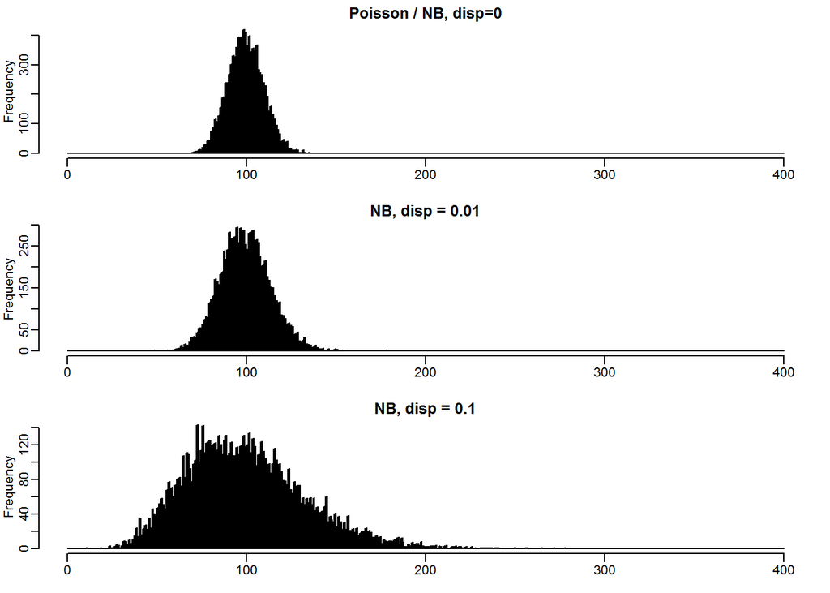

  ```r
  library(rafalib)
  mypar(3,1)
  n <- 10000
  brks <- 0:400
  hist(rpois(n,lambda=100),
       main="Poisson / NB, disp=0",xlab="",breaks=brks,col="black")
  hist(rnbinom(n,mu=100,size=1/.01), #size = 1/dispersion
       main="NB, disp = 0.01",xlab="",breaks=brks,col="black")
  hist(rnbinom(n,mu=100,size=1/.1),
       main="NB, disp = 0.1",xlab="",breaks=brks,col="black")
  ```

- The variance of the negative binomial is equivalent to $\mu + \mu^2*\alpha$

  ```r
  x <- rpois(10000,lambda =100) #Equivalent to NB with dispersion = 0
  #mean; dispersion; variance
  mean(x); (sd(x)/mean(x))^2; mean(x) + (mean(x)^2)*(0)
  ```

  ```
  ## [1] 100.0241
  ```

  ```
  ## [1] 0.009877619
  ```

  ```
  ## [1] 100.0241
  ```

  ```r
  x <- rnbinom(10000,mu=100,size=1/.1)
  #mean; dispersion; variance
  mean(x); (sd(x)/mean(x))^2; mean(x) + (mean(x)^2)*(0.1)
  ```

  ```
  ## [1] 99.3232
  ```

  ```
  ## [1] 0.1109211
  ```

  ```
  ## [1] 1085.833
  ```

- Why model $q_{ij}$ instead of just normalize it to some standardization factor?
  - Alternatives:
    1. Negative binomial model = $K_{ij} \sim \text{NB}(s_{ij} q_{ij}, \alpha_i )$
    2. Basic standardization = $\frac{K_{ij}}{s_{ij}} \sim \mathcal{L}(\mu_{ij} = q_{ij})$
       - Here $q_{ij}$ is just the result of dividing raw counts ($K_{ij}$) by a standardization factor ($s_{ij}$)
  - When a Poisson variable is scaled directly by a factor, it changes both the mean and the variance
    - So while scaling by a size factor my normalize the mean, it will artificially skew the variance
      - Variables that are scaled up will have increased variance and variables that are scaled down will have reduced variance

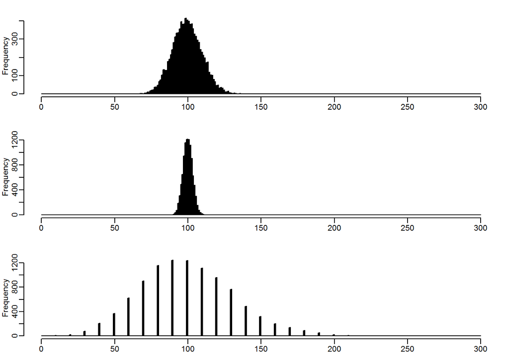

  ```r
  mypar(3,1)
  n <- 10000
  brks <- 0:300
  ###All three distributions have the same mean
  hist(rpois(n,100),main="",xlab="",breaks=brks,col="black") #Base 100
  hist(rpois(n,1000)/10,main="",xlab="",breaks=brks,col="black") #1000 transformed to 100
  hist(rpois(n,10)*10,main="",xlab="",breaks=brks,col="black") #10 transformed to 100
  ```

  ```r
  data.frame("Base.100" = c(mean(rpois(n,100)), sd(rpois(n,100))),
             "1000.to.100" = c(mean(rpois(n,1000)/10), sd(rpois(n,1000)/10)),
             "10.to.100" = c(mean(rpois(n,10)*10), sd(rpois(n,10)*10)),
             row.names = c("mean", "sd"))
  ```

  ```
  ##      Base.100 X1000.to.100 X10.to.100
  ## mean 99.99670    99.948030   99.55200
  ## sd   10.14161     3.153281   31.73043
  ```

  - Once you introduce the possibility of scaled counts/variance, it becomes unclear what the true distribution of a given variable is
    - I.e. a gene with a mean of 100 could derive from any of the three plots above (or more), even though only one would be the true distribution

### Differential gene expression with DESeq2

**Initializing DESeq2 workflow**

```r
library(airway)
library(DESeq2)
data("airway")
dds <- DESeqDataSet(airway, design= ~ cell + dex)
```

**Differential expression output**

```r
library(DESeq2)
dds$dex <- relevel(dds$dex, "untrt") #Ensures that "untrt" is the base level for expression
dds <- DESeq(dds)
res <- results(dds)
head(res)
```

```
## log2 fold change (MAP): dex trt vs untrt
## Wald test p-value: dex trt vs untrt
## DataFrame with 6 rows and 6 columns
##                    baseMean log2FoldChange      lfcSE       stat
##                   <numeric>      <numeric>  <numeric>  <numeric>
## ENSG00000000003 708.6021697    -0.37415246 0.09884435 -3.7852692
## ENSG00000000005   0.0000000             NA         NA         NA
## ENSG00000000419 520.2979006     0.20206175 0.10974241  1.8412367
## ENSG00000000457 237.1630368     0.03616686 0.13834540  0.2614244
## ENSG00000000460  57.9326331    -0.08445399 0.24990710 -0.3379415
## ENSG00000000938   0.3180984    -0.08413903 0.15133427 -0.5559813
##                       pvalue        padj
##                    <numeric>   <numeric>
## ENSG00000000003 0.0001535422 0.001289269
## ENSG00000000005           NA          NA
## ENSG00000000419 0.0655868755 0.197066699
## ENSG00000000457 0.7937652378 0.913855995
## ENSG00000000460 0.7354072485 0.884141561
## ENSG00000000938 0.5782236283          NA
```

- `stat` is the `log2FoldChange` divided by `lfcSE` (i.e the test statistic), which will determine the `pval`
- DESeq2 determines `padj` by a modified Benjamini-Hochberg FDR
  - Instead of just applying the FDR on everything, DESEq2 first applies “independent-filtering” to exclude many genes from the possible significance tests
    - “The goal of independent filtering is to filter out those tests from the procedure that have no, or little chance of showing significant evidence, without even looking at their test statistic”
  - Criteria for a good independent filter include:
    1. It is statistically independent from the test statistic under the null hypothesis,
    2. It is correlated with the test statistic under the alternative
    3. It does not notably change the dependence structure -if there is any- between the tests that pass the filter, compared to the dependence structure between the tests before filtering
  - The default independent filter for DESeq2 is the “mean of normalized counts”
    - Genes with very low counts are not likely to see significant differences

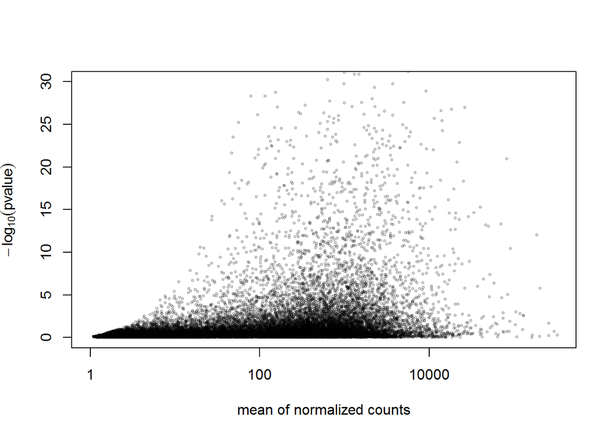

[output not shown]

```r
plot(res$baseMean+1, -log10(res$pvalue),
log="x", xlab="mean of normalized counts",
ylab=expression(-log[10](pvalue)),
ylim=c(0,30),
cex=.4, col=rgb(0,0,0,.3))
```

**MA plots**

- MA plots show each gene by the mean of its counts across all sample vs. it’s fold change between conditions

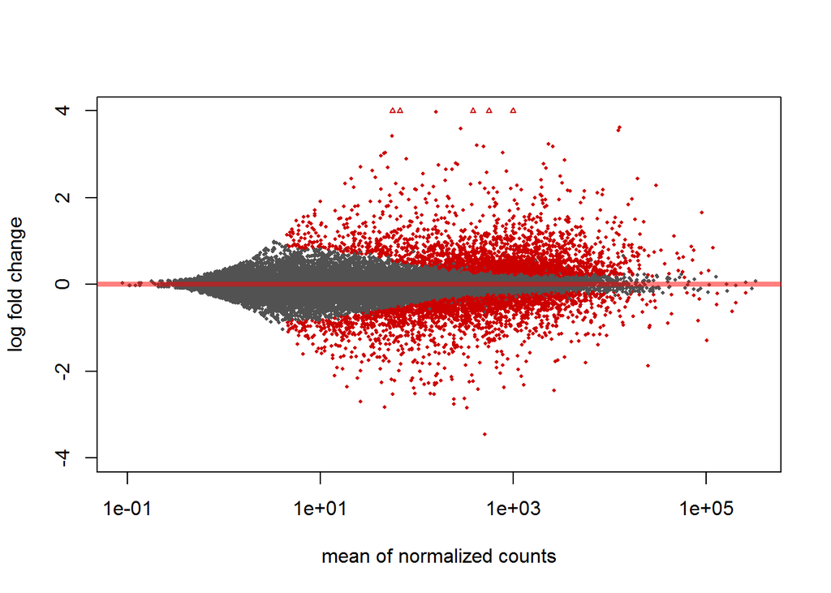

  ```r
  plotMA(res, ylim=c(-4,4))
  ```

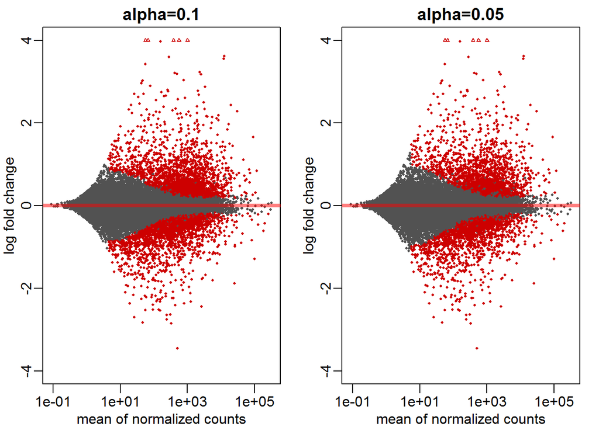

  ```r
  library(rafalib); library(DESeq2)
  mypar(1,2)
  res2 <- results(dds, alpha=0.05)
  plotMA(res, ylim=c(-4,4), main = "alpha=0.1")
  plotMA(res2, ylim=c(-4,4), main = "alpha=0.05")
  ```

- MA plots can also be adjusted to only display significiant differential expression that reaches a fold-change threshold
  - Normally, all fold changes which are significant are indicated
  - `lfcThreshold` argument in `results` can specify a cut off +“lfc” stands for log fold change

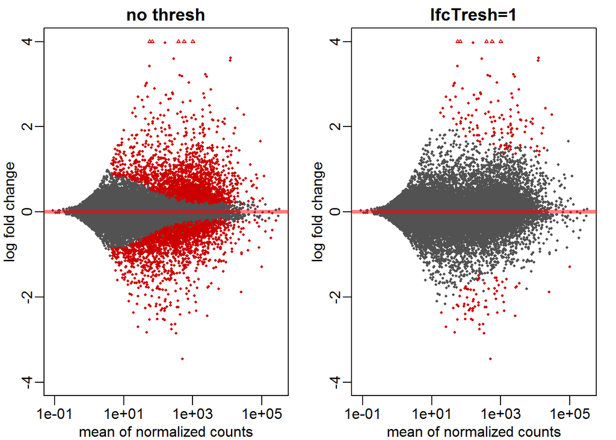

  ```r
  library(rafalib); library(DESeq2)
  mypar(1,2)
  res3 <- results(dds, lfcThreshold = 1)
  plotMA(res, ylim=c(-4,4), main = "no thresh")
  plotMA(res3, ylim=c(-4,4), main = "lfcTresh=1")
  ```

**Individual genes**

- Sorting genes by p-value can highlight important genes

  ```r
  resSort <- res[order(res$padj),]
  head(resSort)
  ```

  ```
  ## log2 fold change (MAP): dex trt vs untrt
  ## Wald test p-value: dex trt vs untrt
  ## DataFrame with 6 rows and 6 columns
  ##                   baseMean log2FoldChange     lfcSE      stat
  ##                  <numeric>      <numeric> <numeric> <numeric>
  ## ENSG00000152583   997.4398       4.313961 0.1721375  25.06114
  ## ENSG00000165995   495.0929       3.186823 0.1281565  24.86665
  ## ENSG00000101347 12703.3871       3.618734 0.1489434  24.29604
  ## ENSG00000120129  3409.0294       2.871488 0.1182491  24.28337
  ## ENSG00000189221  2341.7673       3.230395 0.1366746  23.63567
  ## ENSG00000211445 12285.6151       3.553360 0.1579821  22.49216
  ##                        pvalue          padj
  ##                     <numeric>     <numeric>
  ## ENSG00000152583 1.320082e-138 2.379844e-134
  ## ENSG00000165995 1.708459e-136 1.540005e-132
  ## ENSG00000101347 2.158519e-130 1.297126e-126
  ## ENSG00000120129 2.937761e-130 1.324049e-126
  ## ENSG00000189221 1.657244e-123 5.975359e-120
  ## ENSG00000211445 4.952520e-112 1.488067e-108
  ```

- Can plot expression levels between groups for individual genes

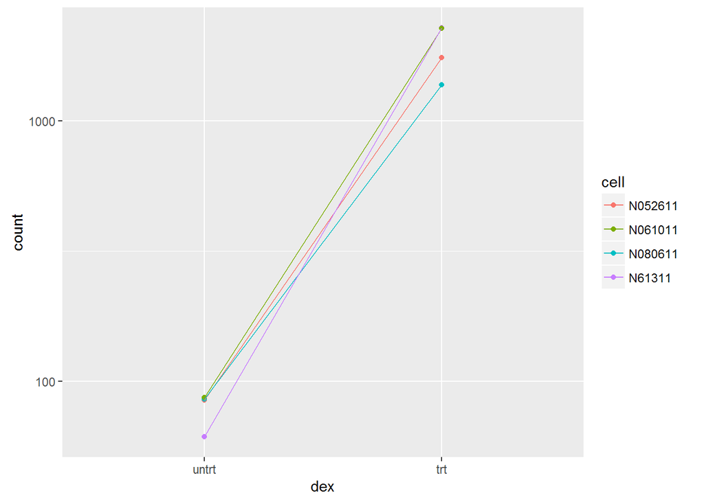

  ```r
  library(ggplot2)
  top.gene  <- which.min(res$padj) #selects gene with lowest adjusted pvalue
  data <- plotCounts(dds, gene=top.gene, intgroup=c("dex","cell"), returnData=TRUE) #extracts expression data from top.gene
      #If returnData=F, would generate a base graphics plot itself
  ggplot(data, aes(x=dex, y=count, col=cell, group=cell)) +
    geom_point() + geom_line() + scale_y_log10()
  ```

**Heatmap of top genes**

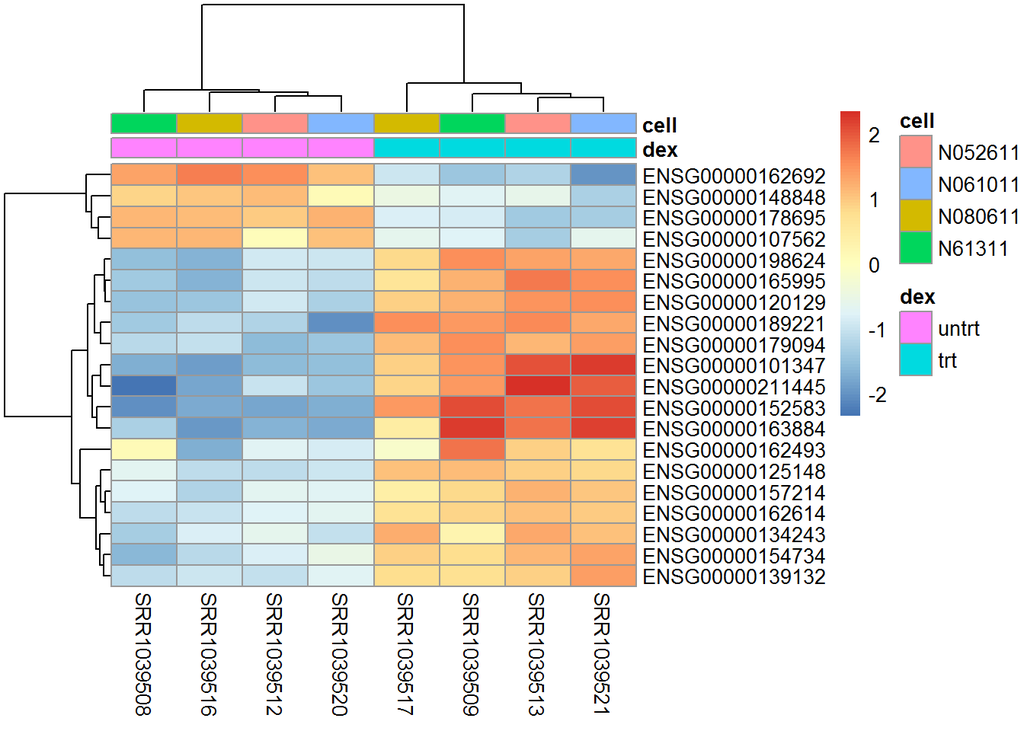

```r
library(pheatmap)
topgenes <- head(rownames(resSort),20)
rld <- rlog(dds, blind=FALSE)
mat <- assay(rld)[topgenes,]
mat <- mat - rowMeans(mat)
df <- as.data.frame(colData(dds)[,c("dex","cell")])
pheatmap(mat, annotation_col=df)
```

### Finding hidden structure with surrogate variable analysis

- SVA can be used to discover hidden data structure
- SVA functions by removing *batch effects* in high-throughput data
  - A batch effect is sub-group measurement that differ sacross conditions due to biological/scientifically irrelevant reasons
  - E.g. one set of samples generated by one individual and a second set generated by another individual
- Running SVA
  - First, isolate data to usefull samples

  ```r
  library(sva)
  dat <- counts(dds)
  dat <- counts(dds, normalized=TRUE)
  idx <- rowMeans(dat) > 1 ###index samples with reasonably high average counts
  dat <- dat[idx,]
  ```

- Create a model matrix for the data indicating sample conditions
  - In this example (airway data), there are two known conditions: dexamethasone and cell type
  - However, we are going to leave out cell type, to see if SVA can detect the effects of this variable without it being specified

  ```r
  mod <- model.matrix(~ dex, colData(dds))
  ```

- Create a null model matrix that does not adjust for any variables

  ```r
  mod0 <- model.matrix(~ 1, colData(dds))
  ```

- Run SVA analysis and plot data based on the new surrogate variables

  ```r
  svseq <- svaseq(dat, mod, mod0, n.sv=2) #n.sv indicates number of surrogate variables to estimate
  ```

  ```
  ## Number of significant surrogate variables is:  2
  ## Iteration (out of 5 ):1  2  3  4  5
  ```

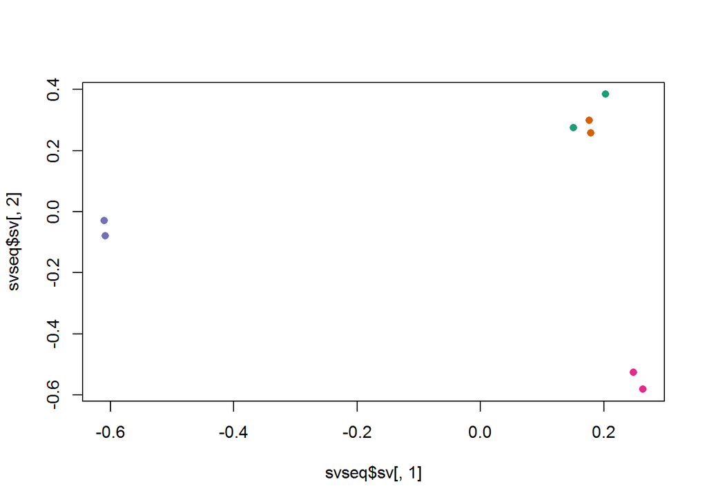

  ```r
  plot(svseq$sv[,1], svseq$sv[,2], col=dds$cell, pch=16)
  ```

  - Notice that the SVA was reasonably able to separate samples by cell type, without being explicity provided that variable
- These surrogate variables can be added to the original data, which can then be rerun using DESeq2 to give a revised anaylsis of sample differences

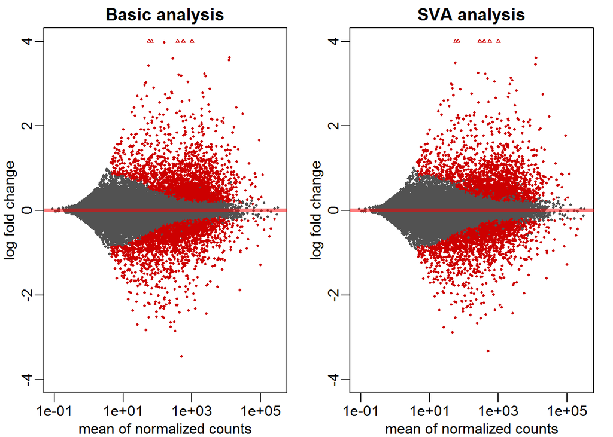

  ```r
  library(rafalib)
  dds.sva <- dds #Sets up a copy of dds data
  dds.sva$SV1 <- svseq$sv[,1]
  dds.sva$SV2 <- svseq$sv[,2]
  design(dds.sva) <- ~ SV1 + SV2 + dex
  dds.sva <- DESeq(dds.sva) #Output is new dds anaysis based an addition of surrogate variables
  mypar(1,2)
  res <- results(dds)
  res.sva <- results(dds.sva)
  plotMA(res, ylim=c(-4,4), main = "Basic analysis")
  plotMA(res.sva, ylim=c(-4,4), main = "SVA analysis")
  ```

### Gene annotation with Bioconductor

- `org.Hs.eg.db` is a package containing an object with annotation for all human genes
- The annotation variables in `org.Hs.eg.db` can be viewed with `columns(org.Hs.eg.db)`

  ```
  ##  [1] "ACCNUM"       "ALIAS"        "ENSEMBL"      "ENSEMBLPROT"
  ##  [5] "ENSEMBLTRANS" "ENTREZID"     "ENZYME"       "EVIDENCE"
  ##  [9] "EVIDENCEALL"  "GENENAME"     "GO"           "GOALL"
  ## [13] "IPI"          "MAP"          "OMIM"         "ONTOLOGY"
  ## [17] "ONTOLOGYALL"  "PATH"         "PFAM"         "PMID"
  ## [21] "PROSITE"      "REFSEQ"       "SYMBOL"       "UCSCKG"
  ## [25] "UNIGENE"      "UNIPROT"
  ```

- `org.Hs.eg.db` can be queried with `select(org.Hs.eg.db, key, columns, keytype)`
  - `key` is an object or vector of genes to be queried in the database
  - `keytype` specifies what form of data `key` is in (e.g. ENSEMBL, SYMBOL, etc.)
  - `columns` specifies what annotation data to return

  ```r
  gene <- rownames(head(resSort)) #Top padj genes from above
  select(org.Hs.eg.db, keys=gene, columns=c("ENSEMBL", "SYMBOL"), keytype=c("ENSEMBL"))
  ```

  ```
  ##           ENSEMBL  SYMBOL
  ## 1 ENSG00000152583 SPARCL1
  ## 2 ENSG00000165995  CACNB2
  ## 3 ENSG00000101347  SAMHD1
  ## 4 ENSG00000120129   DUSP1
  ## 5 ENSG00000189221    MAOA
  ## 6 ENSG00000211445    GPX3
  ```